# Human Activity Recognition - selecting a Classifier for Activity Correctness

Prabha Pillay

16 September 2014

### Overview

This project pertains to the field of study is known as Human Activity Recognition and concerns the quantification of correctness of activity. More specifically, accelerometer data was obtained from six participants, each performing Unilateral Dumbbell Biceps Curls five different ways - one correct and four incorrect. The dataset was supplied by the Groupware@LES research group (http://groupware.les.inf.puc-rio.br/har).

The goal was to derive a prediction model that could be applied to out-of-sample test data.

### Exploratory Data Analysis

The initial dataset comprised 19622 rows of 160 variables. Visual inspection showed many columns to be blank or contain NA values.

```r
# read in training data, setting empty cells to NA
training <- read.csv("./pml-training.csv",na.strings=c("NA",""))
```

### Data Cleanup

Removing columns that were more than 97% blank or NA reduced the number of columns to 60

```r
# establish which columns comprise more than 97% NA values and remove them
na_count <- colSums(is.na(training))
mostly_na <- na_count[na_count>0.97*nrow(training)]
training2 <- training[,-which(names(training) %in% names(mostly_na))]

# convert two non-numeric columns to factors
training2$user_name <- as.factor(training2$user_name)
training2$classe <- as.factor(training2$classe)
```

Near-zero-variance analysis identified another column for removal (“new_window”).

```r
#look for columns with very little variance
nsv <- nearZeroVar(training2,saveMetrics=TRUE)
nsv[nsv$nzv==TRUE,]
```

```
##            freqRatio percentUnique zeroVar  nzv
## new_window        47          0.01   FALSE TRUE
```

This and three timestamp columns and a X index were also removed, having been judged to not contribute to the outcome.

```r
#remove the column identified above, along with the timestamp columns and X index
columns_to_go <- c(-1,-3,-4,-5,-6)
training3 <- (training2[columns_to_go])
```

Interestingly, analysis with the timestamp columns left in actually revealed two of them to be the best predictors of outcome. It is hypothesised that this may be because the sequence of exercises were performed in a fixed order. Given that the true objective of the study was the analysis of biometric activity monitor data, the timestamps were judged to be confounders and removed.

### Data Partitioning

The test dataset is so small (20 rows) that it cannot be used to estimate the out of sample error: cross-validation is the only option. For this reason, a cross-validation set is partitioned from the original training data and used to estimate the error from a suitable fitted model.

Given the size of the dataset, a 60:40 ratio was chosen.

```r
# partition the data into training and cross-validation sets
inTrain <- createDataPartition(y=training3$classe,p=0.6,list=FALSE)
training4 <- training3[inTrain,]
cv4 <- training3[-inTrain,]
```

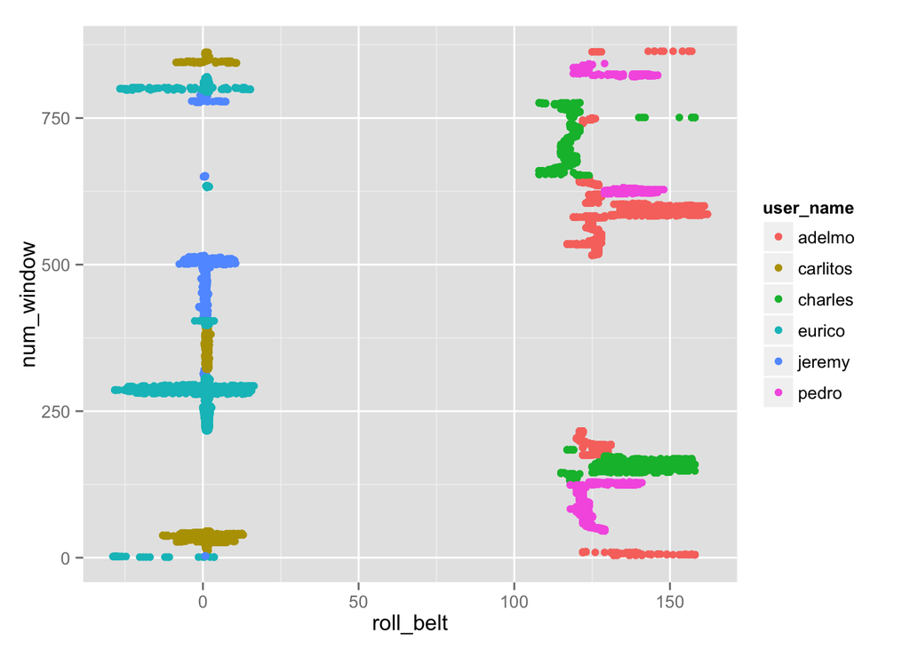

```r
par(mfrow = c(1,2))
qplot(roll_belt,num_window,colour=user_name,data=training4)
```

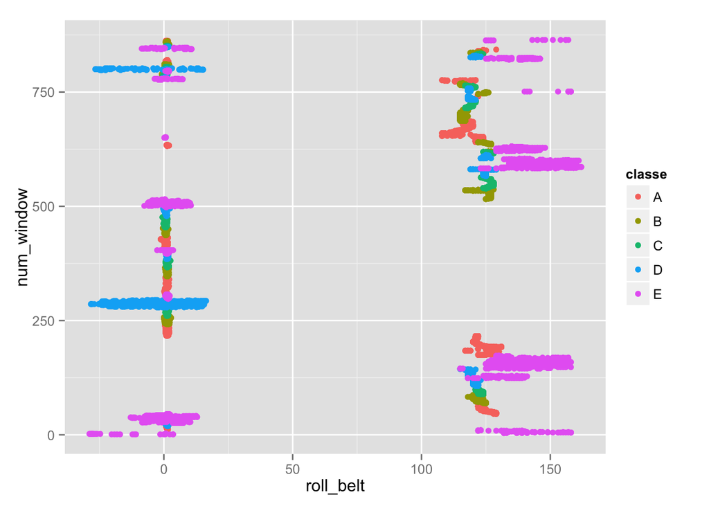

```r
qplot(roll_belt,num_window,colour=classe,data=training4)
```

These two plots show two of the predictors plotted against each other, coloured by user name in the first instance, and by class outcome in the second. There are several foci for each class value, but they tend to be well defined. A sophisticated training machine may be able to learn demarcations for them.

### Training Run 1

Linear Discriminant Analysis was the first training method chosen.

```r
# run LDA training
bootControl <- trainControl(number = 200)
modFit <- train(classe ~ .,data=training4,method="lda",trControl=bootControl,verbose=F)
```

The derived LDA model was used to generate predictions for the cross-validation set, which were then compared to the actual values.

```r
pred_cv <- predict(modFit,cv4)
cfm1 <- confusionMatrix(pred_cv, cv4$classe)
cfm1
```

```
## Confusion Matrix and Statistics
##
##           Reference
## Prediction    A    B    C    D    E
##          A 1919  227  125   76   57
##          B   60 1010  118   56  184
##          C  114  194  965  152   87
##          D  138   44  137  984  127
##          E    1   43   23   18  987
##
## Overall Statistics
##
##                Accuracy : 0.748
##                  95% CI : (0.738, 0.757)
##     No Information Rate : 0.284
##     P-Value [Acc > NIR] : <2e-16
##
##                   Kappa : 0.68
##  Mcnemar's Test P-Value : <2e-16
##
## Statistics by Class:
##
##                      Class: A Class: B Class: C Class: D Class: E
## Sensitivity             0.860    0.665    0.705    0.765    0.684
## Specificity             0.914    0.934    0.916    0.932    0.987
## Pos Pred Value          0.798    0.707    0.638    0.688    0.921
## Neg Pred Value          0.942    0.921    0.936    0.953    0.933
## Prevalence              0.284    0.193    0.174    0.164    0.184
## Detection Rate          0.245    0.129    0.123    0.125    0.126
## Detection Prevalence    0.306    0.182    0.193    0.182    0.137
## Balanced Accuracy       0.887    0.800    0.810    0.849    0.836
```

### Training Run 2

The exercise was repeated - this time, using a Gradient Boosting Classifier as the training method.

```r
# run GBM training
modFit2 <- train(classe ~ ., data=training4, method="gbm",verbose=F)
```

```r
# use the derived GBM model to generate predictions for the cross-validation set,
# and then compare with the actual values
pred_cv2 <- predict(modFit2,cv4)
cfm2 <- confusionMatrix(pred_cv2, cv4$classe)
pred_train2 <- predict(modFit2,training4)
cfm2t <- confusionMatrix(pred_train2, training4$classe)
cfm2
```

```
## Confusion Matrix and Statistics
##
##           Reference
## Prediction    A    B    C    D    E
##          A 2224   33    0    0    0
##          B    7 1469    9    7    9
##          C    0   14 1357   11    0
##          D    1    2    2 1267    6
##          E    0    0    0    1 1427
##
## Overall Statistics
##
##                Accuracy : 0.987
##                  95% CI : (0.984, 0.989)
##     No Information Rate : 0.284
##     P-Value [Acc > NIR] : <2e-16
##
##                   Kappa : 0.984
##  Mcnemar's Test P-Value : NA
##
## Statistics by Class:
##
##                      Class: A Class: B Class: C Class: D Class: E
## Sensitivity             0.996    0.968    0.992    0.985    0.990
## Specificity             0.994    0.995    0.996    0.998    1.000
## Pos Pred Value          0.985    0.979    0.982    0.991    0.999
## Neg Pred Value          0.999    0.992    0.998    0.997    0.998
## Prevalence              0.284    0.193    0.174    0.164    0.184
## Detection Rate          0.283    0.187    0.173    0.161    0.182
## Detection Prevalence    0.288    0.191    0.176    0.163    0.182
## Balanced Accuracy       0.995    0.981    0.994    0.992    0.995
```

The accuracy was much improved over the LDA approach (98.7% up from 74.75%).

### Data Pre-Processing

Another approach was now tried. A pre-processing step was undertaken, whereby Principal Component Analysis was applied to the numeric columns on the training dataset. This step also applied a scaling and centering process to the predictors to standardize them.

```r
# for a third option, apply PCA to the numeric columns of the training set
# to reduce the number of predictors
nums2 <- sapply(training4, is.numeric)
preProcTransformation <- preProcess(training4[,nums2], method = "pca", thresh = 0.95)
trainPC <- predict(preProcTransformation,training4[,nums2])
dim(trainPC)
```

```
## [1] 11776    27
```

95% of the variance of 53 numeric columns could be expressed with 27 Principal Components. The non-numeric columns were recombined, and the generated pre-processing transformation was also applied to the cross-validation set.

```r
# Re-combine with the two non-numeric columns
training5 <- cbind(trainPC,training4[,!nums2])

# Apply the training pre-processing transformation to the cross-validation set
# to derive the same Principal Components
cvPC <- predict(preProcTransformation,cv4[,nums2])
# Recombine with the non-numeric columns
cv5 <- cbind(cvPC,cv4[,!nums2])
```

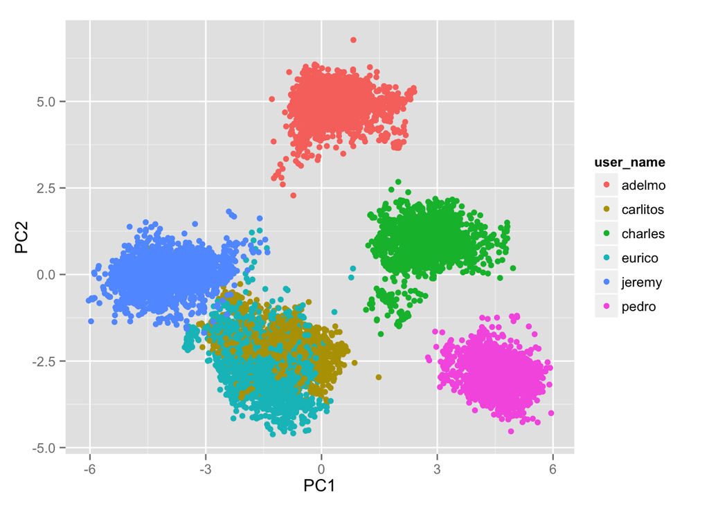

```r
par(mfrow = c(1,2))
qplot(PC1,PC2,colour=user_name,data=training5)
```

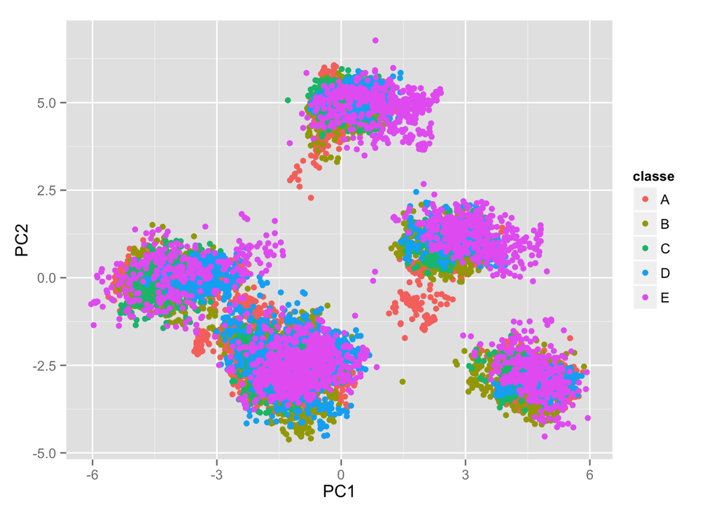

```r
qplot(PC1,PC2,colour=classe,data=training5)
```

These two plots show the two most signficant principal components plotted against each other, coloured by user name in the first instance, and by class outcome in the second. The first plot shows clear segregation by user, suggesting that some standardization of data parameters between users would be a useful pre-processing exercise.

### Training Run 3

The same two methods of LDA and GBM were applied to the pre-processed training set to generate two new models. These were applied in turn to the pre-processed cross-validation set, and the predictions were compared with the actual values.

```r
# run LDA training on the principal components
modFit3 <- train(classe ~ .,data=training5,method="lda",trControl=bootControl,verbose=F)
```

```r
# use the derived LDA model to generate predictions for the cross-validation set,
# and then compare with the actual values
pred_cv3 <- predict(modFit3,cv5)
cfm3 <- confusionMatrix(pred_cv3, cv5$classe)
cfm3
```

```
## Confusion Matrix and Statistics
##
##           Reference
## Prediction    A    B    C    D    E
##          A 1651  289  252   89  139
##          B  100  737  127  163  291
##          C  183  298  827  184  196
##          D  270  121  134  735  162
##          E   28   73   28  115  654
##
## Overall Statistics
##
##                Accuracy : 0.587
##                  95% CI : (0.576, 0.598)
##     No Information Rate : 0.284
##     P-Value [Acc > NIR] : <2e-16
##
##                   Kappa : 0.476
##  Mcnemar's Test P-Value : <2e-16
##
## Statistics by Class:
##
##                      Class: A Class: B Class: C Class: D Class: E
## Sensitivity             0.740   0.4855    0.605   0.5715   0.4535
## Specificity             0.863   0.8924    0.867   0.8953   0.9619
## Pos Pred Value          0.682   0.5197    0.490   0.5169   0.7283
## Neg Pred Value          0.893   0.8785    0.912   0.9142   0.8866
## Prevalence              0.284   0.1935    0.174   0.1639   0.1838
## Detection Rate          0.210   0.0939    0.105   0.0937   0.0834
## Detection Prevalence    0.308   0.1807    0.215   0.1812   0.1145
## Balanced Accuracy       0.801   0.6889    0.736   0.7334   0.7077
```

### Training Run 4

```r
# run GBM training on the principal components
modFit4 <- train(classe ~ ., data=training5, method="gbm",verbose=F)
```

```r
# use the derived GBM model to generate predictions for the cross-validation set,
# and then compare with the actual values
pred_cv4 <- predict(modFit4,cv5)
cfm4 <- confusionMatrix(pred_cv4, cv5$classe)
cfm4
```

```
## Confusion Matrix and Statistics
##
##           Reference
## Prediction    A    B    C    D    E
##          A 1977  162   70   48   34
##          B   44 1139  102   41  117
##          C   74  153 1130  143   71
##          D  105   32   45 1022   70
##          E   32   32   21   32 1150
##
## Overall Statistics
##
##                Accuracy : 0.818
##                  95% CI : (0.809, 0.826)
##     No Information Rate : 0.284
##     P-Value [Acc > NIR] : <2e-16
##
##                   Kappa : 0.77
##  Mcnemar's Test P-Value : <2e-16
##
## Statistics by Class:
##
##                      Class: A Class: B Class: C Class: D Class: E
## Sensitivity             0.886    0.750    0.826    0.795    0.798
## Specificity             0.944    0.952    0.932    0.962    0.982
## Pos Pred Value          0.863    0.789    0.719    0.802    0.908
## Neg Pred Value          0.954    0.941    0.962    0.960    0.956
## Prevalence              0.284    0.193    0.174    0.164    0.184
## Detection Rate          0.252    0.145    0.144    0.130    0.147
## Detection Prevalence    0.292    0.184    0.200    0.162    0.161
## Balanced Accuracy       0.915    0.851    0.879    0.878    0.890
```

### Classifier Comparison

The pre-processing step of transforming the number of predictors to a smaller number of Principal Components seemed to have a detrimental effect on the accuracy outcomes. In the case of the GBM training method, accuracy regressed from 98.7% to 81.8%.

The lower performance of the LDA classifier indicates that a linear solution cannot be derived for this data set. A key requirment for good performance is that the predictors are normally distributed. This may not be the case.

Our best model is therefore the GBM training method, applied to the predictors without a PCA pre-processing step.

### Test Data Preparation

The test data is now loaded and the same cleanup applied.

```r
# load the test data, and
# remove the same NA, low-variance and redundant columns as for the training data
testing <- read.csv(".//pml-testing.csv",na.strings=c("NA","","#DIV/0!"))
testing2 <- testing[,-which(names(testing) %in% names(mostly_na))]
testing3 <- (testing2[columns_to_go])
testing3$user_name <- as.factor(testing3$user_name)
```

### Generating Test Data Predictions

The most successful model, modFit2, is then applied to the test data to generate a set of predicted outcomes.

```r
# apply our most successful model, as indicated by the cross-validation check,
# to the test data
pred_test <- predict(modFit2,testing3)
```

The twenty generated predictions were submitted for the second part of the project using the supplied code, and a 100% score was achieved. A zero error rate is consistent with the very low value of the expected out of sample error.

### Conclusion

Two different classifiers were applied, with and without a PCA pre-processing step to the problem of classifiying correctness of a specific activity. The best of the four approaches had a very low out of sample error when applied to both a validation dataset and a smaller test dataset. Given the noted variety of inputs from a range of test subjects, it displays a promising level of robustness.